# Analyzing Data Collected From .txt Files

# Reading in and analyzing cloud and temperature data from .txt files

For this project, I had to read in 7 different variables relating to atmospheric temperature, each with 72 timepoint locations. The variables are stored in .txt files and were loaded into R and seperated into 4 different columns. The variables are low clouds, mid clouds, high clouds, ozone, pressure, surface temperature and temeprature. The columns will show latitude, longitude, value of variable, and time taken

```r
setwd("C:/Users/Der-chan/Documents/STA 141/NASA")
library(reshape2)
txtfiles=list.files(pattern="*.txt")

ffs=lapply(txtfiles,function(f){
  paste0(f)
  x=read.table(f,skip=7,strip.white=T)
  x=x[-(2:3)]
  date=scan(f,skip=4,nlines=1,what=character())[3]
  long=scan(f,skip=5,nlines=2,what=character())[1:24]
  colnames(x)=c("lat",long)
  ff=melt(x,id.vars="lat",variable.name="long")
  ff$date=date
  ff
})
```

This function retrieves all values from .txt files in the specified directory. From this I have 504 (72 .txt files for 7 variables) different elements. Now its time to split them up into individual variables.

```r
cloudhigh = do.call(rbind, ffs[1:72]) #numbers for the next variable start every 72 .txt files
cloudlow = do.call(rbind, ffs[73:144])
cloudmid = do.call(rbind, ffs[145:216])
ozone = do.call(rbind, ffs[217:288])
pressure = do.call(rbind, ffs[289:360])
surftemp = do.call(rbind, ffs[361:432])
temperature = do.call(rbind, ffs[433:504])
```

An example of the completed data frame

```r
summary(cloudhigh)
```

```
##       lat             long           value          date
##  1.2N   : 1728   113.8W : 1728   Min.   : 0.0   Length:41472
##  1.2S   : 1728   111.2W : 1728   1st Qu.: 1.5   Class :character
##  11.2N  : 1728   108.8W : 1728   Median : 8.5   Mode  :character
##  11.2S  : 1728   106.2W : 1728   Mean   :12.0
##  13.8N  : 1728   103.8W : 1728   3rd Qu.:18.5
##  13.8S  : 1728   101.2W : 1728   Max.   :62.5
##  (Other):31104   (Other):31104
```

```r
head(cloudhigh)
```

```
##     lat   long value        date
## 1 36.2N 113.8W  26.0 16-JAN-1995
## 2 33.8N 113.8W  20.0 16-JAN-1995
## 3 31.2N 113.8W  16.0 16-JAN-1995
## 4 28.8N 113.8W  13.0 16-JAN-1995
## 5 26.2N 113.8W   7.5 16-JAN-1995
## 6 23.8N 113.8W   8.0 16-JAN-1995
```

# Step 2

For this part I needed to check and see if the 7 variables correspond to points on the same grid, in the same order. The “identical” function checks this for me, and shows whether the points are identical or not. For this data to all correspond, Latitude, longitude, and time need to all be equal accross all 7 datasets.

```r
identical(paste(cloudhigh$lat, cloudhigh$long, cloudhigh$date), paste(cloudlow$lat, cloudlow$long, cloudlow$date))
```

```
## [1] TRUE
```

```r
identical(paste(cloudmid$lat, cloudmid$long, cloudmid$date), paste(cloudlow$lat, cloudlow$long, cloudlow$date))
```

```
## [1] TRUE
```

```r
identical(paste(cloudmid$lat, cloudmid$long, cloudmid$date), paste(ozone$lat, ozone$long, ozone$date))
```

```
## [1] TRUE
```

```r
identical(paste(pressure$lat, pressure$long, pressure$date), paste(ozone$lat, ozone$long, ozone$date))
```

```
## [1] TRUE
```

```r
identical(paste(pressure$lat, pressure$long, pressure$date), paste(surftemp$lat, surftemp$long, surftemp$date))
```

```
## [1] TRUE
```

```r
identical(paste(temperature$lat, temperature$long, temperature$date), paste(surftemp$lat, surftemp$long, surftemp$date))
```

```
## [1] TRUE
```

Since they all came up as “TRUE”, I can conclude that all 7 variables correspond to the same dataset. The next step would be to combine all 7 variables into 1 dataframe. This dataframe will have 7 columns for each of the variables, and an extra 3 for latitude, longitude and time, for a total of 10 variables.

```r
library("plyr")
```

```r
clouddata = cbind(cloudlow$value, cloudmid$value, cloudhigh$value, ozone$value, pressure$value, surftemp$value, temperature)
clouddata =  rename(clouddata, c("cloudlow$value"= "cloudlow" , "cloudmid$value" = "cloudmid", "cloudhigh$value" = "cloudhigh", "ozone$value" = "ozone", "pressure$value" = "pressure", "surftemp$value" = "surftemp", "value" = "temperature"))

head(clouddata)
```

```
##   cloudlow cloudmid cloudhigh ozone pressure surftemp   lat   long
## 1      7.5     34.5      26.0   304      835    272.7 36.2N 113.8W
## 2     11.5     32.5      20.0   304      940    279.5 33.8N 113.8W
## 3     16.5     26.0      16.0   298      960    284.7 31.2N 113.8W
## 4     20.5     14.5      13.0   276      990    289.3 28.8N 113.8W
## 5       26     10.5       7.5   274     1000    292.2 26.2N 113.8W
## 6       30      9.5       8.0   264     1000    294.1 23.8N 113.8W
##   temperature        date
## 1       272.1 16-JAN-1995
## 2       282.2 16-JAN-1995
## 3       285.2 16-JAN-1995
## 4       290.7 16-JAN-1995
## 5       292.7 16-JAN-1995
## 6       293.6 16-JAN-1995
```

An extra file with elevation is also needed. This file is loaded seperately due to it ending in a “.dat”, which is because it is time-insensitive.

```r
#reads "intlvtn.dat" and shows values in the sequence
setwd("C:/Users/Der-chan/Documents/STA 141/NASA")
elevation = readLines("intlvtn.dat")
elevation = unlist(strsplit(elevation[2:25]," "))
newelevation = elevation [-seq(1,576,25)]

#remove the selected sequence

newelevation = (as.vector(as.numeric(newelevation)))
elevation = rep(newelevation, times = 72)

#fits elevation for our dataset and names it

clouddata["elevation"] <- NA
clouddata$elevation <- as.numeric(elevation)
head(clouddata)
```

```
##   cloudlow cloudmid cloudhigh ozone pressure surftemp   lat   long
## 1      7.5     34.5      26.0   304      835    272.7 36.2N 113.8W
## 2     11.5     32.5      20.0   304      940    279.5 33.8N 113.8W
## 3     16.5     26.0      16.0   298      960    284.7 31.2N 113.8W
## 4     20.5     14.5      13.0   276      990    289.3 28.8N 113.8W
## 5       26     10.5       7.5   274     1000    292.2 26.2N 113.8W
## 6       30      9.5       8.0   264     1000    294.1 23.8N 113.8W
##   temperature        date elevation
## 1       272.1 16-JAN-1995   1526.25
## 2       282.2 16-JAN-1995   1759.56
## 3       285.2 16-JAN-1995   1948.38
## 4       290.7 16-JAN-1995   2241.31
## 5       292.7 16-JAN-1995   1692.75
## 6       293.6 16-JAN-1995    865.19
```

From this head() function we can see “elevation” was loaded and incorporated successfully

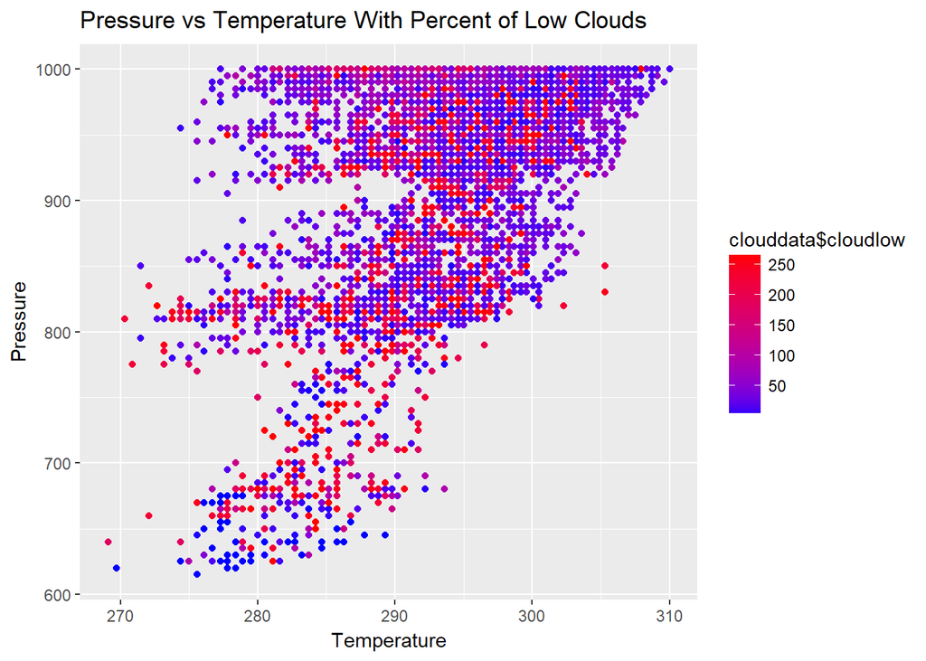

```r
#transform value to numeric for qplot
clouddata[,1:6]= as.numeric(as.character(unlist(clouddata[,1:6])))

#use ggplot to make the graph
library(ggplot2)
qplot(data = clouddata, x = clouddata$temperature, y = clouddata$pressure, color = clouddata$cloudlow, main = "Pressure vs Temperature With Percent of Low Clouds", xlab = "Temperature", ylab = "Pressure" ) + scale_color_gradient(low = "blue", high = "red")
```

Display the average value for pressure on a map.

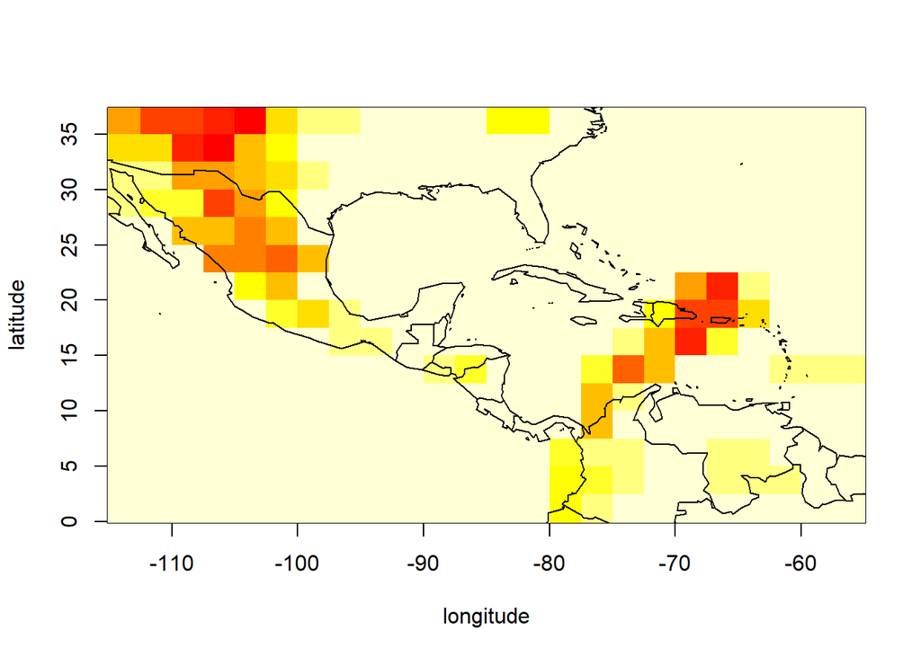

```r
clouddata$lat = as.character(clouddata$lat)
clouddata$lat = substr(clouddata$lat,1,nchar(clouddata$lat)-1)
clouddata$lat = as.numeric(clouddata$lat)

clouddata$long = as.character(clouddata$long)
clouddata$long = substr(clouddata$long,1,nchar(clouddata$long)-1)
clouddata$long = as.numeric(clouddata$long)



pm = with(clouddata, by(clouddata$pressure, list(-long, lat), mean))

dn = dimnames(pm)
x = as.numeric(dn[[1]])
y = as.numeric(dn[[2]])

image(x, y, pm, xlab = "longitude", ylab = "latitude")

library(maps)
map(xlim = range(x),  ylim = range(y), add = TRUE)
```